# Local Item Dependency

Psychologische Institut für psychologische Methodenlehre, Evaluation und Statistik

~

Carolina Fellinghauer

carolina.fellinghauer@uzh.ch

21 4 2020

```r
library(eRm)
library(PP)
library(iarm)
library(corrplot)
library(igraph)
library(R2R)
```

and load the Stress Related Growth (SRG) data:

```r
# get the SRG data set from GitHub

urlfile <- "https://raw.githubusercontent.com/CarolinaFellinghauer/UNIZH_HS2020_Rasch/master/Data/SRG_Data_Course_UNIZH.csv?token=AB5GB47UIUWV7F5NMGA33T27K5IQ2"

srg.data <- read.csv(url(urlfile))

dim(srg.data)
```

```
[1] 450  26
```

```r
colnames(srg.data)
```

```
 [1] "X"                      "ID"                     "Age"
 [4] "Gender"                 "Completeness"           "para.tetra_1"
 [7] "traumatic_nontraumatic" "PersStat"               "SRG1"
[10] "SRG2"                   "SRG3"                   "SRG4"
[13] "SRG5"                   "SRG6"                   "SRG7"
[16] "SRG8"                   "SRG9"                   "SRG10"
[19] "SRG11"                  "SRG12"                  "SRG13"
[22] "SRG14"                  "SRG15"                  "TP"
[25] "ID_Unik"                "wgt"
```

```r
srg.items <- c("SRG1", "SRG2", "SRG3", "SRG4", "SRG5", "SRG6", "SRG7", "SRG8", "SRG9",
    "SRG10", "SRG11", "SRG12", "SRG13", "SRG14", "SRG15")


# dataset with only the capacity items
data.srg <- srg.data[, srg.items]
```

# Local Item Dependency

Testing local item dependencies (LID) is important in Rasch analysis. Local independence means that items are not correlated beyond what can be explained by the common underlying latent variable. Items are expected to be conditionally independent given the latent variable. Violations can lead to inflated estimates of reliability and problems with construct validity (Baghaei 2008).

The most widely reported fit statistic is the $Q_3$ which is just another name for the correlation between Rasch residuals (Yen 1984).

Another fit statistic, that only applies to the Rasch model, and is less frequently reported, is the partial gamma coefficient, which is conditioning with respect to a rest score from which only one item has been subtracted (Kreiner and Christensen 2003).

We illustrate both of these approaches.

# Diagnostics

## Numeric Output Analysis

Prior to extracting Rasch residuals, a Partial Credit Model (`PCM`) and the person parameters (`person.parameter()`) of the PCM are computed.

```r
PCM.srg <- PCM(data.srg)
PP.srg <- person.parameter(PCM.srg)
```

Having the person parameter, the Rasch residuals can be obtained.

```r
resid.srg <- residuals(PP.srg)  # Calculates the Rasch residuals.
dim(resid.srg)  # number of rows (persons) and number of columns(items) for the residuals
```

```
[1] 438  15
```

There are residuals for 438 out of 450 cases. In fact, for extreme scores the ability estimate cannot be obtained with the implemented ML item dfficulty estimation method and ability estimates are needed to find the residuals.  
Another reason to exclude persons from the analysis could also be a high number of missing values, but this is not the case in this data.

If we want a list of the id numbers of the people without residuals, we can get that:

```r
Rows <- rownames(resid.srg)  # gives the original rownumber preceded with a P

# extracting the rownumber of the excluded persons
extrm <- which(1:nrow(data.srg) %in% as.numeric(substr(Rows, 2, nchar(Rows))) ==
    FALSE)
data.srg[extrm, ]  # we see these are only persons with 0 or 2 answers
```

```
    SRG1 SRG2 SRG3 SRG4 SRG5 SRG6 SRG7 SRG8 SRG9 SRG10 SRG11 SRG12 SRG13 SRG14
32     0    0    0    0    0    0    0    0    0     0     0     0     0     0
68     0    0    0    0    0    0    0    0    0     0     0     0     0     0
71     2    2    2    2    2    2    2    2    2     2     2     2     2     2
103    0    0    0    0    0    0    0    0    0     0     0     0     0     0
157    0    0    0    0    0    0    0    0    0     0     0     0     0     0
196    0    0    0    0    0    0    0    0    0     0     0     0     0     0
259    2    2    2    2    2    2    2    2    2     2     2     2     2     2
290    0    0    0    0    0    0    0    0    0     0     0     0     0     0
330    0    0    0    0    0    0    0    0    0     0     0     0     0     0
351    0    0    0    0    0    0    0    0    0     0     0     0     0     0
383    2    2    2    2    2    2    2    2    2     2     2     2     2     2
394    0    0    0    0    0    0    0    0    0     0     0     0     0     0
    SRG15
32      0
68      0
71      2
103     0
157     0
196     0
259     2
290     0
330     0
351     0
383     2
394     0
```

```r
# minimum or maximum score
```

The persons with no residuals are extreme observations with absolute minimum or absolute maximum score.

The analysis of the local item dependency is only interested in the dependencies between items, the few excluded cases (2.6 %) in this sample would not make a significant difference. For that reason we can proceed.  
If there is local independence we expect the latent variable to explain all the correlations between the items. This means that the correlations between residuals should be very small. Correlations between residuals are called $Q_3$ values (Yen 1984). These $Q3$ values are used to evaluate whether items are locally dependent. When investigating LID only the positive correlations are relevant.

Before we analyse the residual correlations we have a look at the regular item correlations:

```r
cor.items.srg <- cor(data.srg, use = "pairwise.complete.obs", method = "spearman")  # item correlations

round(cor.items.srg, digits = 2)  # rounding to 2 decimals
```

```
      SRG1 SRG2 SRG3 SRG4 SRG5 SRG6 SRG7 SRG8 SRG9 SRG10 SRG11 SRG12 SRG13
SRG1  1.00 0.37 0.32 0.23 0.30 0.44 0.44 0.34 0.48  0.39  0.46  0.40  0.31
SRG2  0.37 1.00 0.38 0.33 0.45 0.47 0.42 0.40 0.27  0.34  0.21  0.39  0.18
SRG3  0.32 0.38 1.00 0.39 0.30 0.52 0.54 0.31 0.33  0.27  0.30  0.43  0.34
SRG4  0.23 0.33 0.39 1.00 0.48 0.36 0.38 0.35 0.38  0.37  0.29  0.23  0.29
SRG5  0.30 0.45 0.30 0.48 1.00 0.44 0.44 0.52 0.42  0.45  0.31  0.29  0.33
SRG6  0.44 0.47 0.52 0.36 0.44 1.00 0.60 0.52 0.48  0.50  0.36  0.52  0.35
SRG7  0.44 0.42 0.54 0.38 0.44 0.60 1.00 0.43 0.49  0.44  0.43  0.46  0.42
SRG8  0.34 0.40 0.31 0.35 0.52 0.52 0.43 1.00 0.43  0.41  0.34  0.40  0.27
SRG9  0.48 0.27 0.33 0.38 0.42 0.48 0.49 0.43 1.00  0.50  0.48  0.41  0.34
SRG10 0.39 0.34 0.27 0.37 0.45 0.50 0.44 0.41 0.50  1.00  0.46  0.36  0.33
SRG11 0.46 0.21 0.30 0.29 0.31 0.36 0.43 0.34 0.48  0.46  1.00  0.41  0.36
SRG12 0.40 0.39 0.43 0.23 0.29 0.52 0.46 0.40 0.41  0.36  0.41  1.00  0.24
SRG13 0.31 0.18 0.34 0.29 0.33 0.35 0.42 0.27 0.34  0.33  0.36  0.24  1.00
SRG14 0.36 0.51 0.42 0.47 0.47 0.40 0.49 0.45 0.46  0.40  0.36  0.49  0.38
SRG15 0.30 0.07 0.15 0.22 0.26 0.28 0.17 0.18 0.23  0.20  0.22  0.18  0.46
      SRG14 SRG15
SRG1   0.36  0.30
SRG2   0.51  0.07
SRG3   0.42  0.15
SRG4   0.47  0.22
SRG5   0.47  0.26
SRG6   0.40  0.28
SRG7   0.49  0.17
SRG8   0.45  0.18
SRG9   0.46  0.23
SRG10  0.40  0.20
SRG11  0.36  0.22
SRG12  0.49  0.18
SRG13  0.38  0.46
SRG14  1.00  0.25
SRG15  0.25  1.00
```

There are high positive correlations between the items. This can be expected if items measure a same construct.

The Rasch residual allow to calculate the so called $Q3$ residual correlations, which are the remaining correlations when controlling for the latent trait measured, here stress related growth.

```r
cor.resid.srg <- cor(resid.srg, use = "pairwise.complete.obs")  # residual correlations

round(cor.resid.srg, digits = 3)  # rounding
```

```
        SRG1   SRG2   SRG3   SRG4   SRG5   SRG6   SRG7   SRG8   SRG9  SRG10
SRG1   1.000 -0.033 -0.131 -0.227 -0.195 -0.069 -0.046 -0.138  0.071 -0.038
SRG2  -0.033  1.000 -0.014 -0.014  0.051  0.011 -0.064  0.022 -0.233 -0.083
SRG3  -0.131 -0.014  1.000  0.037 -0.177  0.078  0.114 -0.194 -0.159 -0.207
SRG4  -0.227 -0.014  0.037  1.000  0.127 -0.175 -0.140 -0.079 -0.082 -0.072
SRG5  -0.195  0.051 -0.177  0.127  1.000 -0.140 -0.127  0.156 -0.088 -0.036
SRG6  -0.069  0.011  0.078 -0.175 -0.140  1.000  0.071  0.036 -0.068  0.043
SRG7  -0.046 -0.064  0.114 -0.140 -0.127  0.071  1.000 -0.136 -0.032 -0.092
SRG8  -0.138  0.022 -0.194 -0.079  0.156  0.036 -0.136  1.000 -0.076 -0.058
SRG9   0.071 -0.233 -0.159 -0.082 -0.088 -0.068 -0.032 -0.076  1.000  0.069
SRG10 -0.038 -0.083 -0.207 -0.072 -0.036  0.043 -0.092 -0.058  0.069  1.000
SRG11  0.096 -0.246 -0.131 -0.102 -0.186 -0.158 -0.063 -0.121  0.087  0.111
SRG12  0.005  0.024  0.017 -0.272 -0.242  0.065  0.064 -0.085 -0.104 -0.078
SRG13 -0.085 -0.200 -0.040 -0.108 -0.108 -0.142 -0.024 -0.097 -0.112 -0.125
SRG14 -0.188  0.110 -0.061  0.054 -0.035 -0.255 -0.101 -0.019 -0.078 -0.120
SRG15  0.031 -0.225 -0.159 -0.080 -0.077 -0.102 -0.259 -0.101 -0.093 -0.136
       SRG11  SRG12  SRG13  SRG14  SRG15
SRG1   0.096  0.005 -0.085 -0.188  0.031
SRG2  -0.246  0.024 -0.200  0.110 -0.225
SRG3  -0.131  0.017 -0.040 -0.061 -0.159
SRG4  -0.102 -0.272 -0.108  0.054 -0.080
SRG5  -0.186 -0.242 -0.108 -0.035 -0.077
SRG6  -0.158  0.065 -0.142 -0.255 -0.102
SRG7  -0.063  0.064 -0.024 -0.101 -0.259
SRG8  -0.121 -0.085 -0.097 -0.019 -0.101
SRG9   0.087 -0.104 -0.112 -0.078 -0.093
SRG10  0.111 -0.078 -0.125 -0.120 -0.136
SRG11  1.000 -0.023 -0.055 -0.148 -0.051
SRG12 -0.023  1.000 -0.141  0.024 -0.138
SRG13 -0.055 -0.141  1.000 -0.052  0.246
SRG14 -0.148  0.024 -0.052  1.000 -0.115
SRG15 -0.051 -0.138  0.246 -0.115  1.000
```

```r
# corrplot(cor.resid.srg) #displays graphically the correlation matrix
```

The size of the correlations changed considerably. The correlation between the residuals are much smaller than the regular item correlations. Many are close to zero and many are negative. Negative correlations between residuals are common and especially seen for short scales. Large negative residual correlations can be an indication of multidimensionality of the scale.

Most studies us cut-off values from 0.2 to 0.3, as a rule of thumb, to decide if the dependency between items is significant. The numeric analysis of the residual correlation matrix implies only to detect the items with dependencies above the chosen cut-off.

The values in the upper and lower triangle of a correlation matrix are identical, symmetrically to the diagonal. The diagonal represents the item’s auto-correlations of 1. For that reason, to avoid duplicates, values of the upper part of the correlation matrix are observed with the function `which()`. See code in the examples for `?upper.tri`.

```r
cor.resid.tri <- cor.resid.srg  #to avoid overwritting the original matrix

# setting values of the lower triangle and the diagonal to missing
cor.resid.tri[lower.tri(cor.resid.tri, diag = TRUE)] <- NA

which(cor.resid.tri > 0.2, arr.ind = TRUE)
```

```
      row col
SRG13  13  15
```

There is only a correlation above 0.2 for the items *SRG13: I learned that it’s okay to ask others for help* and *SRG15: I learned that there are more people who care about me than I thought*.

## Visual Analysis

A visual analysis of the dependencies can be done by mean of an association graph, that highlights items associated above a cut-off. Such a useful function can be found in the package `R2R` and requires simply the entry of `RM`or `PCM` object and the cut-off. Further options for the layout of the figure are also available.

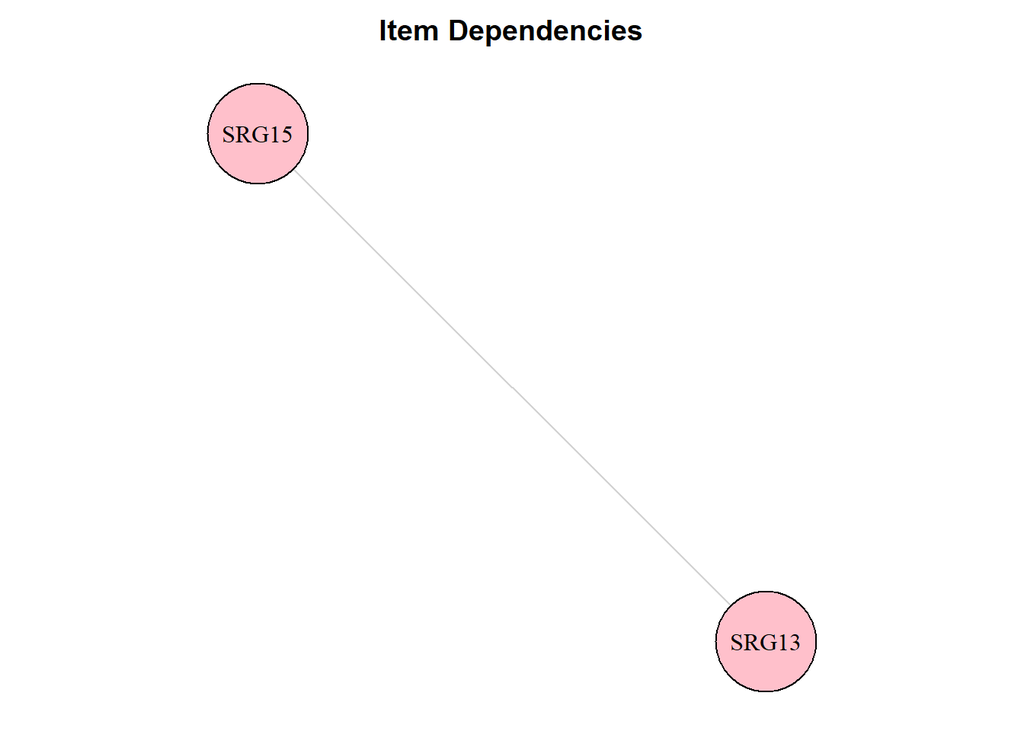

```r
urlfunction <- "https://raw.githubusercontent.com/CarolinaFellinghauer/UNIZH_HS2020_Rasch/master/RFunctions/LIDGraph.R?token=AB5GB42GG6I6YI2MF3KDINC7K5JG6"

source(urlfunction)

LIDgraph(PCM.srg, cut = 0.2, vertex.color = "pink", vertex.size = 40, vertex.label.dist = 0)
```

The visual analysis only confirms what found previously. With a cut-off of $r = 0.2$, one pair of items shows LID, *SRG13* and *SRG15*. This pair of SRG items, has the largest $Q3$ value (0.246). But can we really be sure that this constitutes an anomaly in terms of local dependence? Another strategy to determine the cut-off has been suggested recently.

Marais (2013) recommends that LID should be considered relative to the average of the residual correlations, because the magnitude of the residual correlations depends on the number of items. Christensen, Makransky, and Horton (2017) formalized this, illustrating that if the largest $Q3$ value is more than 0.2 above the average
$$Q^{\star}_3=Q_{3,max}-\bar{Q_3}>0.2$$
this indicates an anomaly.

We try this in the SRG data set, does it make a change to use the mean as cut-off

```r
# selecting the largest Q3 value
Q3.max.srg <- max(cor.resid.srg[(cor.resid.srg < 1)])
Q3.max.srg  #shows the largest Q3 value
```

```
[1] 0.24582
```

```r
Q3.average.srg <- mean(cor.resid.srg[(cor.resid.srg < 1)])  # calculates the average residual                                                           # correlation (without the diagonal)
Q3.average.srg  #shows the average residual correlation
```

```
[1] -0.06896837
```

```r
# calculates the difference between the largest Q3 value and the average residual
# correlation; if this value is bigger than .2 this would indicate LD

Q3.star.srg <- Q3.max.srg - Q3.average.srg
Q3.star.srg  #shows Q3*
```

```
[1] 0.3147884
```

As the difference between the largest Q3 value and the average residual correlation is larger than .20, there is evidence of LID.

Are other pair of items with residual correlations 0.2 above the average residual correlation? A visual display is more helpful to see where the dependencies are.

```r
# using the mean as cut-off

cut.off.Q3 <- Q3.average.srg + 0.2

cut.off.Q3
```

```
[1] 0.1310316
```

Drawing the association plot for dependencies above $cut$

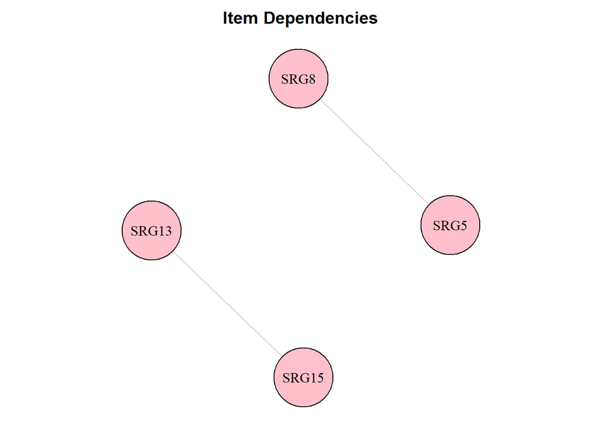

```r
LID_Q3cutoff <- LIDgraph(PCM.srg, cut = cut.off.Q3, vertex.color = "pink", vertex.size = 40,
    vertex.label.dist = 0, print.out = TRUE)
```

```r
LID_Q3cutoff$cut.off
```

```
[1] 0.1310316
```

```r
LID_Q3cutoff$LID
```

```
      SRG1 SRG2 SRG3 SRG4 SRG5 SRG6 SRG7 SRG8     SRG9 SRG10 SRG11 SRG12 SRG13
SRG1  ""   ""   ""   ""   ""   ""   ""   ""       ""   ""    ""    ""    ""
SRG2  ""   ""   ""   ""   ""   ""   ""   ""       ""   ""    ""    ""    ""
SRG3  ""   ""   ""   ""   ""   ""   ""   ""       ""   ""    ""    ""    ""
SRG4  ""   ""   ""   ""   ""   ""   ""   ""       ""   ""    ""    ""    ""
SRG5  ""   ""   ""   ""   ""   ""   ""   "0.1561" ""   ""    ""    ""    ""
SRG6  ""   ""   ""   ""   ""   ""   ""   ""       ""   ""    ""    ""    ""
SRG7  ""   ""   ""   ""   ""   ""   ""   ""       ""   ""    ""    ""    ""
SRG8  ""   ""   ""   ""   ""   ""   ""   ""       ""   ""    ""    ""    ""
SRG9  ""   ""   ""   ""   ""   ""   ""   ""       ""   ""    ""    ""    ""
SRG10 ""   ""   ""   ""   ""   ""   ""   ""       ""   ""    ""    ""    ""
SRG11 ""   ""   ""   ""   ""   ""   ""   ""       ""   ""    ""    ""    ""
SRG12 ""   ""   ""   ""   ""   ""   ""   ""       ""   ""    ""    ""    ""
SRG13 ""   ""   ""   ""   ""   ""   ""   ""       ""   ""    ""    ""    ""
SRG14 ""   ""   ""   ""   ""   ""   ""   ""       ""   ""    ""    ""    ""
SRG15 ""   ""   ""   ""   ""   ""   ""   ""       ""   ""    ""    ""    ""
      SRG14 SRG15
SRG1  ""    ""
SRG2  ""    ""
SRG3  ""    ""
SRG4  ""    ""
SRG5  ""    ""
SRG6  ""    ""
SRG7  ""    ""
SRG8  ""    ""
SRG9  ""    ""
SRG10 ""    ""
SRG11 ""    ""
SRG12 ""    ""
SRG13 ""    "0.2458"
SRG14 ""    ""
SRG15 ""    ""
```

Using this criterion, a relevant dependency is seen between the items *SRG5* and *SRG8* ($r = 0.156$) and *SRG13* and *SRG15* ($r = 0.246$).

The item *SRG5 I learned to work through models and not just give up* and *SRG8 I learned to be a more confident person* both underline same action oriented coping mechanisms.

The items *SRG13 I learned that it’s okay to ask others for help* and *SRG15 I learned that there are more people who care about me than I thought* underline the peer-support.

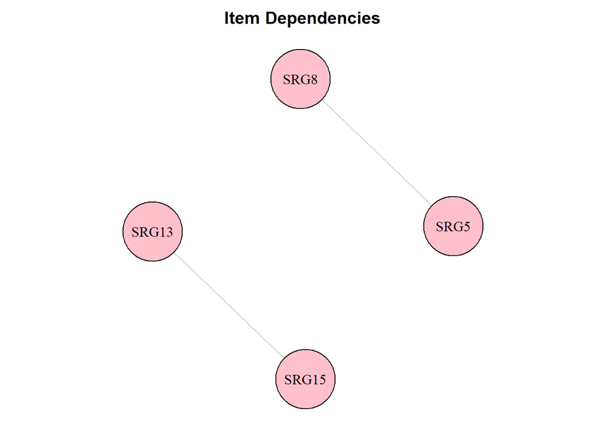

```
$LID
      SRG1 SRG2 SRG3 SRG4 SRG5 SRG6 SRG7 SRG8     SRG9 SRG10 SRG11 SRG12 SRG13
SRG1  ""   ""   ""   ""   ""   ""   ""   ""       ""   ""    ""    ""    ""
SRG2  ""   ""   ""   ""   ""   ""   ""   ""       ""   ""    ""    ""    ""
SRG3  ""   ""   ""   ""   ""   ""   ""   ""       ""   ""    ""    ""    ""
SRG4  ""   ""   ""   ""   ""   ""   ""   ""       ""   ""    ""    ""    ""
SRG5  ""   ""   ""   ""   ""   ""   ""   "0.1561" ""   ""    ""    ""    ""
SRG6  ""   ""   ""   ""   ""   ""   ""   ""       ""   ""    ""    ""    ""
SRG7  ""   ""   ""   ""   ""   ""   ""   ""       ""   ""    ""    ""    ""
SRG8  ""   ""   ""   ""   ""   ""   ""   ""       ""   ""    ""    ""    ""
SRG9  ""   ""   ""   ""   ""   ""   ""   ""       ""   ""    ""    ""    ""
SRG10 ""   ""   ""   ""   ""   ""   ""   ""       ""   ""    ""    ""    ""
SRG11 ""   ""   ""   ""   ""   ""   ""   ""       ""   ""    ""    ""    ""
SRG12 ""   ""   ""   ""   ""   ""   ""   ""       ""   ""    ""    ""    ""
SRG13 ""   ""   ""   ""   ""   ""   ""   ""       ""   ""    ""    ""    ""
SRG14 ""   ""   ""   ""   ""   ""   ""   ""       ""   ""    ""    ""    ""
SRG15 ""   ""   ""   ""   ""   ""   ""   ""       ""   ""    ""    ""    ""
      SRG14 SRG15
SRG1  ""    ""
SRG2  ""    ""
SRG3  ""    ""
SRG4  ""    ""
SRG5  ""    ""
SRG6  ""    ""
SRG7  ""    ""
SRG8  ""    ""
SRG9  ""    ""
SRG10 ""    ""
SRG11 ""    ""
SRG12 ""    ""
SRG13 ""    "0.2458"
SRG14 ""    ""
SRG15 ""    ""

$cut.off
[1] 0.1310316
```

```r
# In principle, it is not necessary to calculate that cut-off and simply put cut
# = 'Q3star'

LIDgraph(PCM.srg, cut = "Q3star", vertex.color = "pink", vertex.size = 40, vertex.label.dist = 0,
    print.out = TRUE)
```

Baghaei, P. 2008. “Local Dependency and Rasch Measures.” *Rasch Measurement Transactions* 21 (3): 1105–6.

Christensen, Karl Bang, Guido Makransky, and Mike Horton. 2017. “Critical Values for Yen’s Q3: Identification of Local Dependence in the Rasch Model Using Residual Correlations.” *Applied Psychological Measurement* 41 (3): 178–94. https://doi.org/doi:10.1177/0146621616677520.

Kreiner, Svend, and Karl Bang Christensen. 2003. *Analysis of Local Dependence and Multidimensionality in Graphical Loglinear Rasch Models*. Copenhagen: Department of Biostatistics, University of Copenhagen.

Marais, Ida. 2013. “Local Dependence.” In *Rasch Models in Health*, 111–30. John Wiley & Sons, Ltd. https://doi.org/10.1002/9781118574454.ch7.

Yen, Wendy M. 1984. “Effects of Local Item Dependence on the Fit and Equating Performance of the Three-Parameter Logistic Model.” *Applied Psychological Measurement* 8 (2): 125–45. https://doi.org/10.1177/014662168400800201.